# Data Exploration Project

Al

3/19/2022

## Preamble

For the purpose of this project, I’ll be taking a look at The College Scorecard (a public-facing website that contains important information about colleges, including how much its graduates earn) and seeing how it effects — if at all — Google Trend results relating to that data.

Most importantly, we want to see if there is a noticeable uptick when the The College Scoreboard is added in September of 2015.

# Data & Libraries

Bringing in our libraries and squeaky clean data

```r
library(tidyverse)
library(car)
library(vtable)
library(jtools)
clean_data <- read_csv('../processed_data/clean_data.csv')
```

## Analysis

Because we’re going to be conducting a difference-in-difference regression, we’re going to set up both a treated and an untreated group. Our goal here is to understand the effects of Google Trend indexes on our “treated” variables (which account for our defined median earnings before and after the scorecard launch)

```r
did_reg <- lm(index_std ~ untreated * treated, data = clean_data)
export_summs(did_reg)
```

|  | Model 1 |
| --- | --- |
| (Intercept) | 0.05 *** |
|  | (0.00) |
| untreatedTRUE | 0.01 * |
|  | (0.00) |
| treatedTRUE | -0.29 *** |
|  | (0.01) |
| untreatedTRUE:treatedTRUE | -0.04 ** |
|  | (0.01) |
| N | 64773 |
| R2 | 0.04 |
| *** p < 0.001; ** p < 0.01; * p < 0.05. |  |

## Visualization

For our visualization, we’ll be graphing our treated (and untreated) values and seeing how they differ in their values based on our difference-in-difference model. Recall that time is being used to dictate “before” and “after”. We’re using the launch of The College Scorecard as that defining point in time.

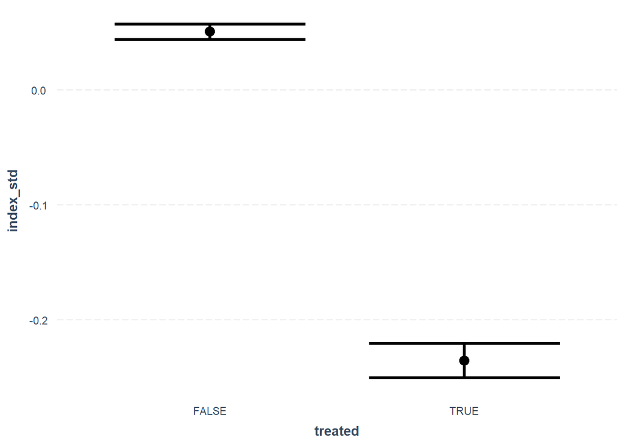

```r
effect_plot(did_reg, pred = treated)
```

## Conclusion

To conclude, it appears that the effect created by The College Board isn’t all that profound when it comes to Google Trends. I actually received results that went against the narrative I personally expected, and so I would conclude that its effects are negligent.